# Competencia de Métodos Avanzados de Estadística - Distribución Conteo

Andrés Franco, Julián Castelblanco y Edgar Alirio Rodríguez

12/Oct/2019

# Introducción

Se procederá a construir uno modelo de prediccción, que responda a los requierimientos propuestos en la competencia, que tiene tres criterios de evaluación:

- Capacidad predictiva específica: 15%
- Capacidad predictiva general : 25%
- Selección de regresores : 25%

*La capacidad predictiva general será el error cuadratico medio(MSE) y para determinar la capacidad predictiva específica será la correcta clasificación de los valores iguales a 0 y mayores a 0 para la variable conteo*.

# 1. Carga de Datos y Análisis Descriptivo

Se cargan todos los datos para la variable respuesta de Conteo (yC) y se identifica el tipo de variable para cada regresor, así:

```r
summary(data[,-1])
```

```
##        yC              x1              x2         x3      x4      x5
##  Min.   :0.000   Min.   :34.22   Min.   :  4.60   0:105   0:128   0:144
##  1st Qu.:0.000   1st Qu.:56.87   1st Qu.: 14.72   1: 45   1: 22   1:  6
##  Median :1.000   Median :67.75   Median : 40.00
##  Mean   :1.307   Mean   :64.32   Mean   : 50.37
##  3rd Qu.:2.000   3rd Qu.:71.52   3rd Qu.: 81.40
##  Max.   :7.000   Max.   :78.84   Max.   :173.70
##  x6      x7            x8              x9             x10
##  0:132   0:135   Min.   :10.62   Min.   : 0.00   Min.   :   1.406
##  1: 18   1: 15   1st Qu.:14.51   1st Qu.:25.50   1st Qu.:  17.241
##                  Median :15.46   Median :31.00   Median :  53.867
##                  Mean   :15.40   Mean   :27.59   Mean   : 139.557
##                  3rd Qu.:16.59   3rd Qu.:39.75   3rd Qu.: 123.527
##                  Max.   :20.85   Max.   :45.00   Max.   :4547.958
##       x11              x12          x13     x14     x15     x16
##  Min.   : 4.948   Min.   : 0.0000   0:115   0:120   0:119   0:120
##  1st Qu.: 6.581   1st Qu.: 0.2606   1: 35   1: 30   1: 31   1: 30
##  Median : 7.749   Median : 2.7141
##  Mean   : 7.804   Mean   : 7.7746
##  3rd Qu.: 8.986   3rd Qu.:10.3450
##  Max.   :10.807   Max.   :47.4765
##  x17     x18     x19     x20          x21              x22
##  0:103   0:135   0:134   0:144   Min.   :0.0004   Min.   :0.000000
##  1: 47   1: 15   1: 16   1:  6   1st Qu.:0.1095   1st Qu.:0.000000
##                                  Median :0.7138   Median :0.000050
##                                  Mean   :0.5580   Mean   :0.006207
##                                  3rd Qu.:0.9144   3rd Qu.:0.000500
##                                  Max.   :0.9897   Max.   :0.790100
##       x23                x24               x25            x26
##  Min.   :0.000000   Min.   :0.00000   Min.   :4.00   Min.   :3.000
##  1st Qu.:0.001625   1st Qu.:0.00000   1st Qu.:6.00   1st Qu.:5.000
##  Median :0.021850   Median :0.00010   Median :6.00   Median :6.000
##  Mean   :0.239536   Mean   :0.03257   Mean   :6.38   Mean   :5.587
##  3rd Qu.:0.415925   3rd Qu.:0.00150   3rd Qu.:7.00   3rd Qu.:6.000
##  Max.   :0.994200   Max.   :0.84660   Max.   :9.00   Max.   :7.000
##       x27         x28     x29          x30             x31
##  Min.   : 11.09   0:130   0:142   Min.   :1.000   Min.   :0.01154
##  1st Qu.: 44.94   1: 20   1:  8   1st Qu.:2.000   1st Qu.:0.10043
##  Median : 66.40                   Median :4.000   Median :0.24764
##  Mean   : 78.49                   Mean   :3.927   Mean   :0.28314
##  3rd Qu.:102.72                   3rd Qu.:6.000   3rd Qu.:0.43699
##  Max.   :344.83                   Max.   :7.000   Max.   :0.66233
##       x32
##  Min.   :0.02304
##  1st Qu.:0.19443
##  Median :0.46109
##  Mean   :0.49105
##  3rd Qu.:0.79795
##  Max.   :0.99633
```

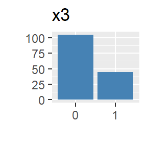

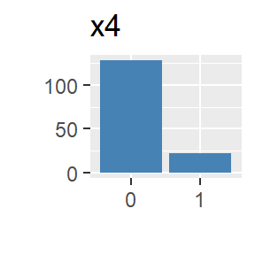

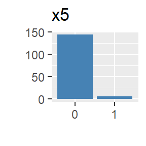

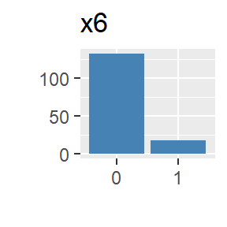

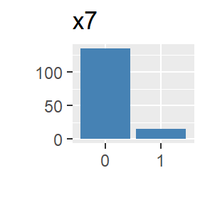

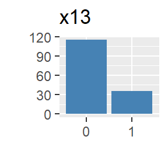

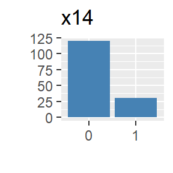

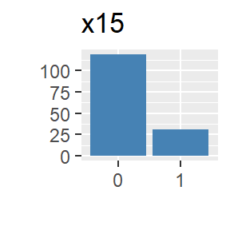

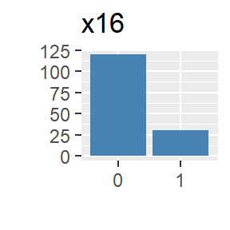

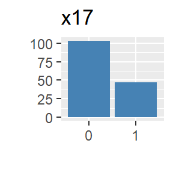

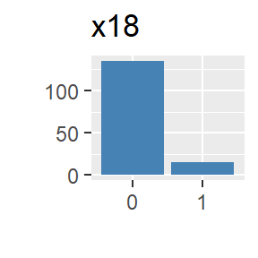

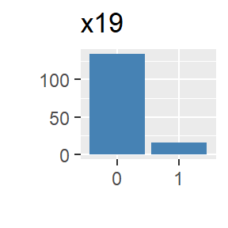

[3 more figures not shown]

### 1.2 Distibucion variables continuas Analizando los histogramas de frecuencias de las variables continuas se identifican casos de variables que las observaciones están concentradas en un rango reducido como por ejemplo las variables: $ x10,x12,x21,x22,x23,x24$ Sólo las variable $x8$ tiene una distribución de frecuencia que se asemeja a una distribución normal.

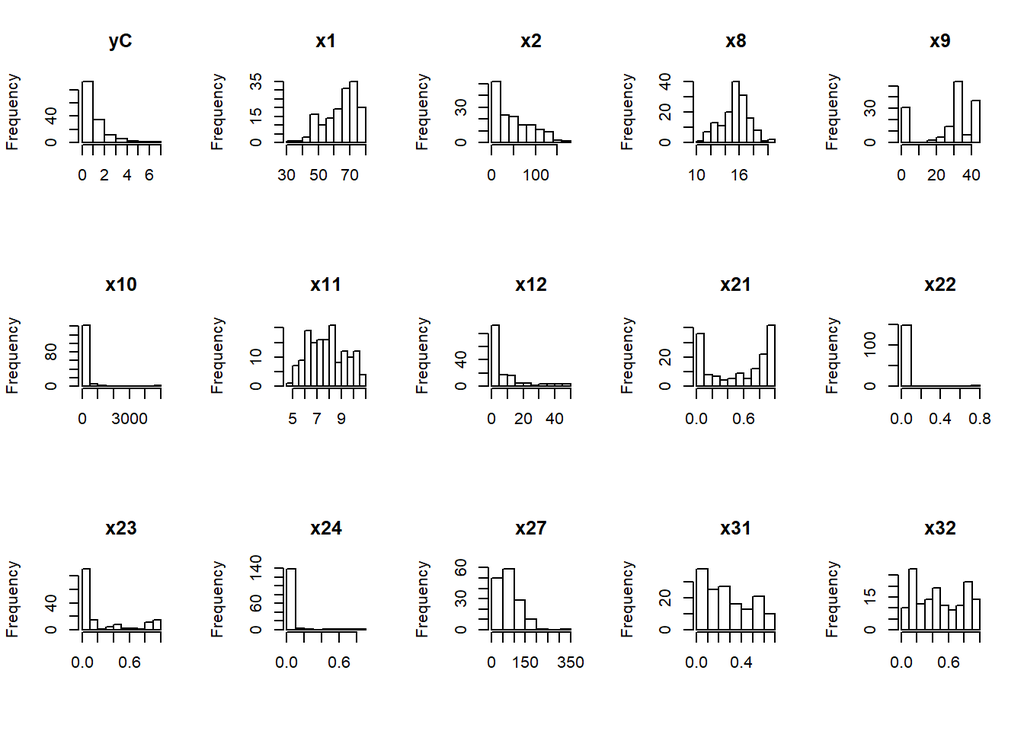

# 2. Limpieza de base de datos

### 2.1. Identificación de Datos Influyentes

Previo a la identificación de los valores influyentes, se va identificar los valores atípicos (*outliers*)

#### Identifación de valores atípicos

Analizando la distribución de todos los datos con los valores mínimos, máximos y la media. Se identifica algunas anomalias entre los valores extremos y el percentil 75, por lo tanto se procede a visualizar un boxplot para identidicar la distribucion de estas variables. Por el momento no se realiazaría ninguna acción sobre estas variables.

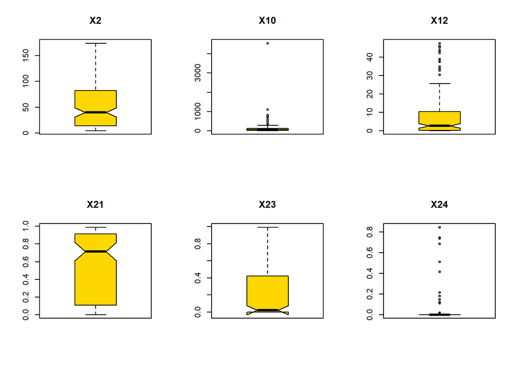

```r
outlierX10<-outliers::outlier(data$x10)
outlierX24<-outliers::outlier(data$x24)
data[data$x10==outlierX10 | data$x27==outlierX24,c("x10","x24")]
```

```
##          x10  x24
## 138 4547.958 0.15
```

Se considera conveniente identificar si existen valores extremos que tengan una influencia significativa en el cálculo de los valores de la regresión 2, para lo que se utilizará la métrica denominada Distancia de *Cook*, que se calcula removiendo del modelo el i-ésimo dato y calculando la regresión, sumando el cambio de todos los valores del modelo de regresión dado que se se removió el el i-ésimo dato. La formula de la distancia de Cook es: $D_i=\frac{\sum_{j=1}^n(\hat{Y}_j - \hat{Y}_{j(i)})^2}{(p+1)\hat{σ}^2}$

Teniendo como referencia del punto de corte la formula $\frac{4}{n-p-1}$, siendo *n* el número de observaciones, *p* el número de variables predictoras.

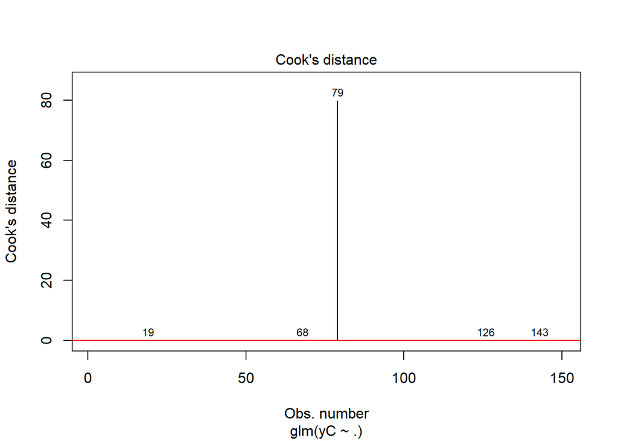

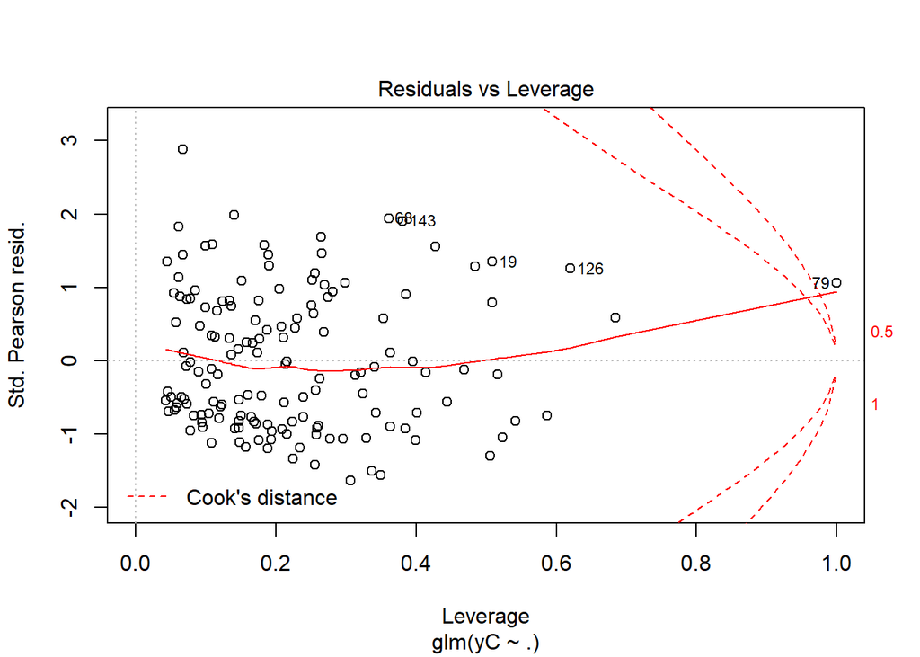

Al analizar la gráfica de la distancia de Cook vs Observaciones, claramente se identifica que el registro 79 tiene una distancia de *Cook* de 79.85 que considerablemente supera el valor de la línea roja o punto de corte que es de0.03. Lo que se ratifica con la gráfica de los Residuales vs Influencia (*Leverage*), en la que se identifica que la observación 79 está superando (a la derecha) la línea roja discontinua que delimita la distancia de *Cook*,lo que indica que corresponde a un valor extremo que tiene una inflencia significativa en el resultado del cálculo de la regresión,

De acuerdo con esto la recomendación es eliminar del conjunto de datos la observación 79 y a varificar como queda la distribución de la distancia de Cook de las restantes observaciones.

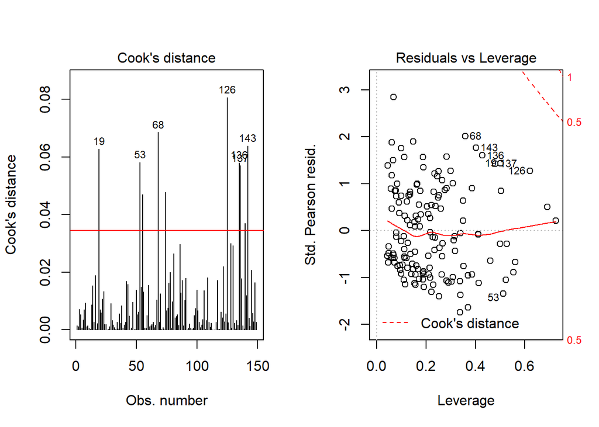

Habiendo retirado la observación 79, en la imagen de la distancia de Cook vs Observaciones se aprecian las observaciones 19, 53, 68, 131, 126, 136,137, y 143, están por encima del limite del punto corte. Sin embargo, en la gráfica de los Residuales vs Influencia, estos puntos se identifica que están a la izquierda de la linea roja puntuada que corresponde al limite de la Diastancia de Cook, por lo que no se considera que sean una observación influyente, por lo que no es necesario retiralo del conjunto de observaciones.

Adicionalmente se realiza la prueba de bonferrini

```
## No Studentized residuals with Bonferroni p < 0.05
## Largest |rstudent|:
##     rstudent unadjusted p-value Bonferroni p
## 55 -2.253508           0.024227           NA
```

Podemos observar que no se encuentran observaciones adicionesles que deben ser eliminada de la base de datos

Podemos observar que todas las observaciones permanecen dentro de los límites, para ser aceptados como valores no influyentes ni *outlier*.

### 2.2 Detectando Multicolinealidad

A continuación se procederá a verificar si existe colinealidad entre dos o más variables predictoras, para lo que se calculará el Factor de Inflación de Varianza (VIF)2, que identifica cómo la varianza de los coeficientes de la regresión son inflados debido a multicolinealidad del modelo. $VIF=\frac{1}{Tol}=\frac{1}{1-R^2}$

El menor valor de VIF es uno (1) que indica ausencia de multicolinealidad. La recomendación es que los valores de VIF que sean mayores de 5 o 10 es un indicio de multicolinealidad, algunas fuentes mencionan que para modelos débiles, a partir de un VIF de 2.5 puede ser un indicio de multicolinealidad y otras afirman que un valor de VIF inferior a 4 se consdiera bueno para el modelo, por lo que se establecerá como valor de referencia de multicolinealidad un valor de 5.

```
## c("x1", "x2", "x21", "x23", "x31", "x32")
```

|  | VIF | collinearity |
| --- | --- | --- |
| x1 | 10.84 | True |
| x2 | 9.90 | True |
| x21 | 8.85 | True |
| x23 | 7.97 | True |
| x31 | 27.94 | True |
| x32 | 26.45 | True |

Después de realizar el cálculo del VIF se identifica que las siguientes variables x1, x2, x21, x23, x31, x32 tienen un valor de VIF superior a 5, por lo que se procederá a calcular cuál es la correlación entre estas variables, dejando solamente las que tengan un valor superior a 0.3.

|  | x1 | x2 | x21 | x23 | x31 | x32 |
| --- | --- | --- | --- | --- | --- | --- |
| x1 |  | 0.94 | 0.32 |  |  |  |
| x2 | 0.94 |  | 0.383 | 0.326 |  |  |
| x21 | 0.32 | 0.383 |  | 0.775 | 0.327 |  |
| x23 |  | 0.326 | 0.775 |  |  |  |
| x31 |  |  | 0.327 |  |  | 0.973 |
| x32 |  |  |  |  | 0.973 |  |

Al verificar los datos de la correlación entre las variables que presentaron multicolinealidad, se identifica que por ejemplo la variable x1 tiene una alta correlación con x2.

Luego se dejan las variables x1, x23 y x32, y se procede a excluir x2, x21, x31. Luego nuevamente se procede a calcular el VIF para comprobar que no exista multicolinealidad.

|  | VIF | collinearity |
| --- | --- | --- |
| x3 | 3.39 | False |
| x4 | 1.52 | False |
| x5 | 1.31 | False |
| x6 | 2.99 | False |
| x7 | 1.31 | False |
| x13 | 2.61 | False |
| x14 | 1.42 | False |
| x15 | 2.04 | False |
| x16 | 2.77 | False |
| x18 | 2.06 | False |
| x19 | 2.21 | False |
| x20 | 1.69 | False |
| x28 | 1.65 | False |
| x29 | 2.30 | False |
| x9 | 1.76 | False |
| x25 | 2.22 | False |
| x26 | 2.43 | False |
| x30 | 2.50 | False |
| x1 | 2.81 | False |
| x8 | 4.17 | False |
| x10 | 1.52 | False |
| x12 | 2.53 | False |
| x27 | 3.44 | False |
| x22 | 1.50 | False |
| x23 | 2.79 | False |
| x24 | 1.49 | False |
| x32 | 1.57 | False |

Luego se detecta que entre las variables que se dejaron en el conjunto de datos, ya NO existen multicolinealidad.

### 2.3 Resumen de Resultados de Intervenciones

Antes de avanzar en la evaluación de modelos, se considera conveniente realizar una evaluación comparativa de los modelos de glm con familia *Poisson* que se han establecido hasta el momento con las exclusiones de datos influyentes y variables que presentan multicolinealidad, lo que nos puede servir como base o referencia.

|  | MSE | BIC | Accuracy |
| --- | --- | --- | --- |
| Todas las variables | 1.0195 | 531.30 | 0.667 |
| Sin Datos Influenciadores | 1.0330 | 526.41 | 0.664 |
| Sin Multicolinealidad ni dato influyente | 1.0356 | 505.73 | 0.664 |

```
## Vuong Non-Nested Hypothesis Test-Statistic:
## (test-statistic is asymptotically distributed N(0,1) under the
##  null that the models are indistinguishible)
## -------------------------------------------------------------
##               Vuong z-statistic             H_A          p-value
## Raw                   -1.320574 model2 > model1         0.093322
## AIC-corrected          1.721157 model1 > model2         0.042611
## BIC-corrected          6.289756 model1 > model2 0.00000000015898
```

Por lo anterior, se continuará evaluando modelos utilizando este conjunto de datos que no tiene el dato influyente y en para el modelo final se tendrá encuenta que no se encuentren variables que presentaban multicolinealidad entre ellas.

**Nota:** Se procede a la estandarización de los variables continuas. En donde se cuentra que las variables x10,x27,x31 presentan distribución lognormal,gamma y beta respectivamente; con ello, se procede a adecuar los valores extremos y estandarizar adecuamente:

$y=(x-min)/range$

# 3. Identificación de Modelos que Mejoren la Predicción

Previo a la identificación de modelos, se procederá a aplicar la validación cruzada en el que se dividen las observaciones del conjunto que no tiene el dato influyente ni las variables que presentaban multicolinealidad, en dos subconjuntos, uno para entrenamiento de los modelos con el 70% de las observaciones, otro subconjunto para evaluar o probar el desempeño de cada modelo con el 30% de las observaciones.

Luego de esta división de las observaciones se tiene que el subconjunto de entrenamiento tiene 106 observaciones y el subconjunto con los datos de prueba tiene 43 observaciones.

### 3.1 Métodos Frecuentistas

#### 3.1.1 Regresión Poisson utilizando el Método Stepwise

Se parte como modelo inicial el modelo base con todas las variables para ir corriendo diferentes modelos para determinar cual es el mejor, esta tecnica va comparando el modelo base quitando o agregando las variables sobre el espacio de los parámetros. La métrica utilizada para seleccionar el mejor modelo en este ejercicio fue $BIC=\ln{n} - 2\ln{\hat{L}}.$ donde: $\hat{L}= p(x|\hat{\theta},M)$ es el valor maximizado de la probabilidad del modelo y $\hat{\theta}$ los parámetros que maximizan la función de verosimilitud.

```
##
## Call:
## glm(formula = yC ~ x3 + x25 + x27, family = "poisson", data = dtConEntrenamiento)
##
## Deviance Residuals:
##      Min        1Q    Median        3Q       Max
## -2.39467  -1.13528  -0.09115   0.61178   1.82737
##
## Coefficients:
##             Estimate Std. Error z value   Pr(>|z|)
## (Intercept)   3.1568     0.6891   4.581 0.00000463 ***
## x31           0.6779     0.1928   3.516   0.000438 ***
## x25          -0.4607     0.1057  -4.358 0.00001311 ***
## x27          -0.8793     0.3871  -2.272   0.023116 *
## ---
## Signif. codes:  0 '***' 0.001 '**' 0.01 '*' 0.05 '.' 0.1 ' ' 1
##
## (Dispersion parameter for poisson family taken to be 1)
##
##     Null deviance: 146.54  on 105  degrees of freedom
## Residual deviance: 103.99  on 102  degrees of freedom
## AIC: 286.33
##
## Number of Fisher Scoring iterations: 5
```

Como resultado de correr el método de Stepwise se identifica las variables seleccionadas en el que sería el mejor modelo son: x31, x25, x27 y que la precisión es de 0.67

#### 3.1.2 Regresion poisson utilizando el Método Ridge

La Regresión Ridge es una metodologia de regularizacion, que busca resolver problemas mal planteados. En este ejercicio sera utilizada para seleccionar variables en modelos glm con un gran numero de parametros.
$$\begin{equation}
\widehat\beta_{Ridge} = (X'X+\lambda I)^{-1}(X'y)
\end{equation}$$
donde $\lambda$ es el parametro de penalización, esta funcion no solo minimiza la funcion de los residuos al cuadrado, si no tambien la estimacion de los parametros reduciendolos a 0.2

```
## 33 x 1 sparse Matrix of class "dgCMatrix"
##                        s0
## (Intercept)  0.7991501888
## x31          0.3169417405
## x41         -0.2331385928
## x51         -0.3037804387
## x61         -0.1275838713
## x71         -0.2645433327
## x131         0.0559566582
## x141        -0.2497108855
## x151        -0.1314613265
## x161        -0.0558808779
## x171         0.1158433567
## x181         0.0820910909
## x191         0.2911381512
## x201         0.0386324857
## x281        -0.1295572657
## x291        -0.0491424253
## x9          -0.0007070817
## x25         -0.2002709950
## x26          0.1382399880
## x30         -0.0020211397
## x1           0.0356094053
## x2          -0.1237365460
## x8          -0.0605323513
## x10         -0.1441415382
## x11         -0.0805945898
## x12         -0.0210737665
## x27         -0.4058013288
## x21          0.0008388060
## x22          0.1974939646
## x23         -0.0045098071
## x24         -0.6628899495
## x31          0.1211177499
## x32          0.1906760448
```

El resultado de correr el método de Ridge Regression, da como reultado un $\lambda=$ 0.79 se identifica las variables seleccionadas en el que sería el mejor modelo son: x31, x41, x51, x61, x71, x131, x141, x151, x161, x171, x181, x191, x201, x281, x291, x9, x25, x26, x30, x1, x2, x8, x10, x11, x12, x27, x21, x22, x23, x24, x31, x32 y que la precisión es de 0.7

#### 3.1.3 Regresion lineal utilizando el Método Lasso

La Regresión Lasso es una metodologia, para seleccion de variables y resolver problemas de regularizacion. En este ejercicio sera utilizada para minimizar la cantidad de parametros de una regresión, que permitan explicar mejor el modelo.
$$\begin{equation}
\beta^* = \min\limits_{\beta \in \mathbb{R}^p} \sum_{i=1}^n \left[y_i- x_i^{'}\beta_i \right]^2 + \lambda \sum_{j=1}^p \mid \beta_j \mid
\end{equation}$$
donde $\lambda$ es el parametro de penalización, esta funcion no solo minimiza la funcion de los residuos al cuadrado, si no tambien la estimación de los parametros reduciendolos a 0. La diferencia entre Lasso y Ridge es la funcion de penalización de los parametros.4

```
## 33 x 1 sparse Matrix of class "dgCMatrix"
##                      s0
## (Intercept)  1.37837736
## x31          0.49157731
## x41         -0.03062403
## x51         -0.25236837
## x61          .
## x71         -0.19457863
## x131         .
## x141        -0.28338117
## x151        -0.17575060
## x161         .
## x171         .
## x181         .
## x191         0.20313201
## x201         .
## x281        -0.06679908
## x291         .
## x9           .
## x25         -0.31668667
## x26          0.14067890
## x30          .
## x1           .
## x2           .
## x8           .
## x10          .
## x11          .
## x12          .
## x27         -0.57642853
## x21          .
## x22          .
## x23          .
## x24         -1.03045613
## x31          .
## x32          0.37611368
```

El resultado de correr el método de Lasso Regression, da como reultado un $\lambda=$ 0.057 se identifica las variables seleccionadas en el que sería el mejor modelo son: x31, x41, x51, x71, x141, x151, x191, x281, x25, x26, x27, x24, x32 y que la precisión es de 0.7

#### 3.1.4 Regresion Poisson utilizando el Método Elastic Net

La metodo de Regresion Elastic Net la cual retiene las ventajas de las metodologias Lasso y Ridge, para la seleccion de variables y resolver problemas de regularización y resolver las limitaciones de seleccionar grupos de variables correlacionadas o datos con alta multicolinealidad.
$$\begin{equation}
\hat \beta^{Elastic} = arg\min\limits_{\beta}(\Vert {y-X\beta} \Vert^2 +\lambda_2 \Vert \beta \Vert^2 + \lambda_1 \Vert \beta \Vert_1 )
\end{equation}$$
donde $\lambda_1, \lambda_2$, son los coeficientes de penalización de la función para los metodos Lasso y Ridge regression.4

```
## 33 x 1 sparse Matrix of class "dgCMatrix"
##                      s0
## (Intercept)  0.77503882
## x31          0.18802635
## x41          .
## x51          .
## x61          .
## x71          .
## x131         .
## x141         .
## x151         .
## x161         .
## x171         .
## x181         .
## x191         .
## x201         .
## x281         .
## x291         .
## x9           .
## x25         -0.16896248
## x26          0.08215695
## x30          .
## x1           .
## x2           .
## x8           .
## x10          .
## x11          .
## x12          .
## x27          .
## x21          .
## x22          .
## x23          .
## x24          .
## x31          .
## x32          .
```

El resultado de correr el método de Elastic Regression, da como reultado un $\lambda=$ 0.506 y $\alpha=$ 0.5 se identifica las variables seleccionadas en el que sería el mejor modelo son: x31, x25, x26 y que la precisión es de 0.7

### 3.2 Enfoques Bayesianos

#### 3.2.1 Promedio del Modelo Bayesiano

Utilizando Bayesian Model Averaging (BMA) es una metodología bayesiana que utiliza una búsqueda estocástica que compara diferentes modelos por su probabilidad aposteriori3, donde propusieron un enfoque de Markov Chain Monte Carlo que se aproxima directamente a la solución exacta, lo que lleva aproxima la respuesta sin tener que calcular $2^p$ modelos diferentes, ya que los procedimientos comunes generalmente requieren mucho tiempo de cómputo para hacer una búsqueda exhaustiva.

Sea $M= \{M_1,M_2, \dotsc,M_{2^k}\}$ el conjunto de todos los modelos posibles, donde cada uno de ellos depende de un conjunto de parámetros $\alpha_j$ $\forall j \in 1,\dotsc,2^k$, $k$ es el número de regresores posibles y $y$ es la variable dependiente, la probabilidad de modelo posterior se define como:
$$\begin{equation}
P(M_j \mid y, M)=\frac{P(y \mid M_j)\pi(M_j)}{\sum_{i=1}^{m}P(y \mid M_i)\pi(M_i)} \hspace{5mm} \forall j=1,2,\dotsc,m
\end{equation}$$

donde,
$$\begin{equation}
P(y \mid M_j)=\int ...\int P(y\mid \alpha_j, \hspace{2mm} M_j)\pi(\alpha_j \mid M_j ) d \alpha_j \hspace{5mm} \forall j=1,2,\dotsc,m
\end{equation}$$

La probabilidad integrada del modelo $M_j$, $\alpha_j$ es el vector de parámetros del modelo $M_j$, $\pi(\alpha_j \mid M_j )$ es la prior de los parámetros bajo $M_j$, $P(y\mid\alpha_j,M_j)$ es la probabilidad y $\pi(M_j)$ es la probabilidad previa del $M_j$ sea el mejor modelo.

```
##
## Call:
## bic.glm.data.frame(x = dtConEntrenamiento[, -1], y = dtConEntrenamiento[,     1], glm.family = "poisson", strict = TRUE, maxCol = 32, nbest = 1000)
##
##
##   6  models were selected
##  Best  5  models (cumulative posterior probability =  0.9481 ):
##
##            p!=0   EV      SD      model 1    model 2    model 3
## Intercept  100    1.9008  2.0583     2.7511     0.4518     3.4386
## x3.x       54.2
##     .1            0.2701  0.2832     0.5068      .          .
## x4.x        0.0
##     .1            0.0000  0.0000      .          .          .
## x5.x        0.0
##     .1            0.0000  0.0000      .          .          .
## x6.x        0.0
##     .1            0.0000  0.0000      .          .          .
## x7.x        0.0
##     .1            0.0000  0.0000      .          .          .
## x13.x       0.0
##      .1           0.0000  0.0000      .          .          .
## x14.x       0.0
##      .1           0.0000  0.0000      .          .          .
## x15.x       0.0
##      .1           0.0000  0.0000      .          .          .
## x16.x       0.0
##      .1           0.0000  0.0000      .          .          .
## x17.x       0.0
##      .1           0.0000  0.0000      .          .          .
## x18.x       0.0
##      .1           0.0000  0.0000      .          .          .
## x19.x       0.0
##      .1           0.0000  0.0000      .          .          .
## x20.x       0.0
##      .1           0.0000  0.0000      .          .          .
## x28.x       0.0
##      .1           0.0000  0.0000      .          .          .
## x29.x       0.0
##      .1           0.0000  0.0000      .          .          .
```

[output cut: 57 more lines]

```
## x2.x           .          .
## x8.x           .          .
## x10.x          .          .
## x11.x          .          .
## x12.x          .          .
## x21.x          .          .
## x22.x          .          .
## x23.x          .          .
## x24.x          .          .
## x31.x          .          .
## x32.x          .          .
##
## nVar            1          2
## BIC        -368.0892  -366.7717
## post prob     0.108      0.056
```

##### Comportamiento de las variables con BMA

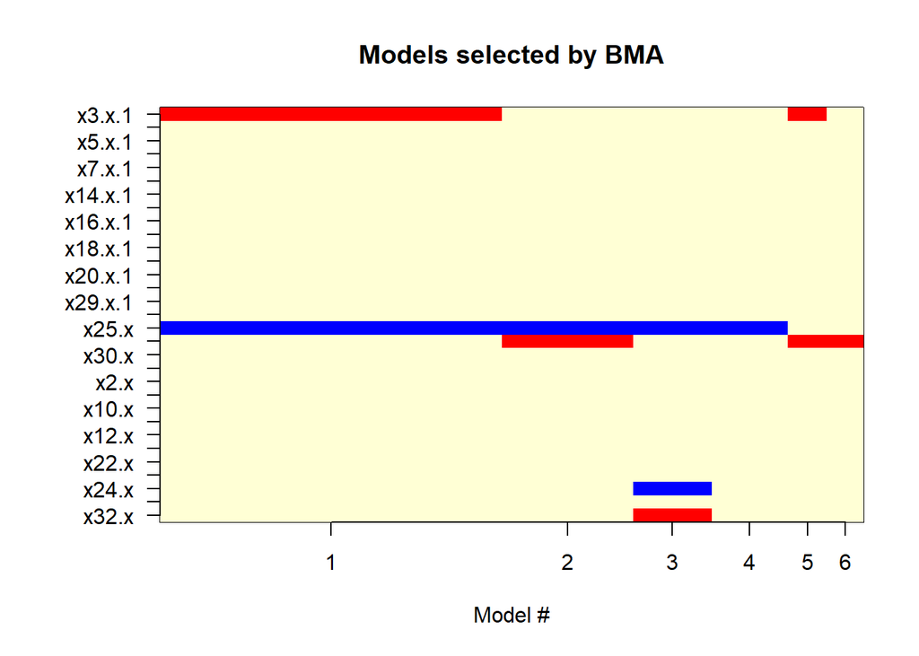

```r
imageplot.bma(bma_poiso_bicreg)
```

```
##
## Call:
## glm(formula = yC ~ x3 + x25 + x32, family = "poisson", data = dtConEntrenamiento)
##
## Deviance Residuals:
##      Min        1Q    Median        3Q       Max
## -2.27861  -1.11771  -0.07925   0.61454   1.81996
##
## Coefficients:
##             Estimate Std. Error z value   Pr(>|z|)
## (Intercept)   2.8186     0.6695   4.210 0.00002550 ***
## x31           0.4669     0.1835   2.545     0.0109 *
## x25          -0.4829     0.1088  -4.440 0.00000899 ***
## x32           0.4482     0.2744   1.634     0.1023
## ---
## Signif. codes:  0 '***' 0.001 '**' 0.01 '*' 0.05 '.' 0.1 ' ' 1
##
## (Dispersion parameter for poisson family taken to be 1)
##
##     Null deviance: 146.54  on 105  degrees of freedom
## Residual deviance: 106.60  on 102  degrees of freedom
## AIC: 288.94
##
## Number of Fisher Scoring iterations: 5
```

# 4. Resumen de Resultados

A continuación se presenta el resumen de los resultados obtenidos con los diferentes métodos.

|  | Núm.Variables | MSE | Accuracy | Efect.por.Variable |
| --- | --- | --- | --- | --- |
| Stepwise con BIC | 3 | 1.0021 | 0.670 | 0.223 |
| Ridge | 32 | 2.0000 | 0.700 | 0.022 |
| Lasso | 13 | 1.6279 | 0.700 | 0.054 |
| Elastic Net | 3 | 1.9302 | 0.700 | 0.233 |
| BMA | 3 | 1.9535 | 0.744 | 0.248 |

Guardar modelo seleccionado:

```r
# Guardar Base Modelo Seleccionado
save(model_bma_pois, file = "ModelCount.RData")
```

## Referencias

[1]Burnham, K. P., & Anderson, D. R. (2004). Multimodel inference: understanding AIC and BIC in model selection. Sociological methods & research, 33(2), 261-304.  
[2]Friedman, J., Hastie, T., & Tibshirani, R. (2010). Regularization paths for generalized linear models via coordinate descent. Journal of statistical software, 33(1), 1.  
[3]Tibshirani, R. (1996). Regression shrinkage and selection via the lasso. Journal of Royal Statistical Society: Series B (methodology), 67(1): 91-108. [4] Zou, H. and Hastie, T. (2005). Regularization and variable selection via the elastic net. Journal of Royal Statistical Society: Series B (methodology), 67(2): 301-320.